# Case study-trip

Bhakti Dangra

2024-07-28

Background

Scenario

You are a junior data analyst working on the marketing analyst team at Cyclistic, a bike-share company in Chicago. The director of marketing believes the company’s future success depends on maximizing the number of annual memberships. Therefore, your team wants to understand how casual riders and annual members use Cyclistic bikes differently. From these insights, your team will design a new marketing strategy to convert casual riders into annual members. But first, Cyclistic executives must approve your recommendations, so they must be backed up with compelling data insights and professional data visualizations.

About the company

In 2016, Cyclistic launched a successful bike-share offering. Since then, the program has grown to a fleet of 5,824 bicycles that are geotracked and locked into a network of 692 stations across Chicago. The bikes can be unlocked from one station and returned to any other station in the system anytime. Until now, Cyclistic’s marketing strategy relied on building general awareness and appealing to broad consumer segments. One approach that helped make these things possible was the flexibility of its pricing plans: single-ride passes, full-day passes, and annual memberships. Customers who purchase single-ride or full-day passes are referred to as casual riders. Customers who purchase annual memberships are Cyclistic members.

Ask

Business Task In order to maximize the number of annual membership, I, data analyst, will find trend and patterns among casual riders and membership riders, and identify potential riders who can get benefit from annual membership. I do not need to raise awareness of annual membership among casual riders as they are already aware of the program.

Stakeholders

The director of marketing The marketing analysis team Cyclistic’s Executive team

Stakeholder’s expectation Design marketing strategies aimed at converting casual riders into annual members. In order to do that, however, the marketing analyst team needs to better understand how annual members and casual riders differ, why casual riders would buy a membership, and how digital media could affect their marketing tactics. The marketing team is interested in analyzing the Cyclistic historical bike trip data to identify trends.

Prepare

DATA TYPE check

1.ROOOC Check 2.Sampling bias 3.Observer bias 4.Interpretation bias 5.Confirmation bias

About the data set:

Install relevant packages

install.packages(“tidyverse”) install.packages(“dplyr”) install.packages(“lubridate”) install.packages(“geosphere”)

Library

```r
library(tidyverse)
```

```r
library(ggplot2)
library(dplyr)
library(tidyr)
library(lubridate)
library(geosphere)
```

Trip Data

```r
tripdata_202401 <- read.csv ("202401-divvy-tripdata.csv")
tripdata_202402 <- read.csv ("202402-divvy-tripdata.csv")
tripdata_202403 <- read.csv ("202403-divvy-tripdata.csv")
tripdata_202404 <- read.csv ("202404-divvy-tripdata.csv")
tripdata_202405 <- read.csv ("202405-divvy-tripdata.csv")
tripdata_202406 <- read.csv ("202406-divvy-tripdata.csv")
```

Data Check

```r
colnames(tripdata_202401)
```

```
##  [1] "ride_id"            "rideable_type"      "started_at"
##  [4] "ended_at"           "start_station_name" "start_station_id"
##  [7] "end_station_name"   "end_station_id"     "start_lat"
## [10] "start_lng"          "end_lat"            "end_lng"
## [13] "member_casual"
```

```r
colnames(tripdata_202402)
```

```
##  [1] "ride_id"            "rideable_type"      "started_at"
##  [4] "ended_at"           "start_station_name" "start_station_id"
##  [7] "end_station_name"   "end_station_id"     "start_lat"
## [10] "start_lng"          "end_lat"            "end_lng"
## [13] "member_casual"
```

```r
colnames(tripdata_202403)
```

```
##  [1] "ride_id"            "rideable_type"      "started_at"
##  [4] "ended_at"           "start_station_name" "start_station_id"
##  [7] "end_station_name"   "end_station_id"     "start_lat"
## [10] "start_lng"          "end_lat"            "end_lng"
## [13] "member_casual"
```

```r
colnames(tripdata_202404)
```

```
##  [1] "ride_id"            "rideable_type"      "started_at"
##  [4] "ended_at"           "start_station_name" "start_station_id"
##  [7] "end_station_name"   "end_station_id"     "start_lat"
## [10] "start_lng"          "end_lat"            "end_lng"
## [13] "member_casual"
```

```r
colnames(tripdata_202405)
```

```
##  [1] "ride_id"            "rideable_type"      "started_at"
##  [4] "ended_at"           "start_station_name" "start_station_id"
##  [7] "end_station_name"   "end_station_id"     "start_lat"
## [10] "start_lng"          "end_lat"            "end_lng"
## [13] "member_casual"
```

```r
colnames(tripdata_202406)
```

```
##  [1] "ride_id"            "rideable_type"      "started_at"
##  [4] "ended_at"           "start_station_name" "start_station_id"
##  [7] "end_station_name"   "end_station_id"     "start_lat"
## [10] "start_lng"          "end_lat"            "end_lng"
## [13] "member_casual"
```

combine data

```r
All_trip <- bind_rows(tripdata_202401,tripdata_202402,tripdata_202403,tripdata_202404,tripdata_202405,tripdata_202406)
```

```r
colnames(All_trip)
```

```
##  [1] "ride_id"            "rideable_type"      "started_at"
##  [4] "ended_at"           "start_station_name" "start_station_id"
##  [7] "end_station_name"   "end_station_id"     "start_lat"
## [10] "start_lng"          "end_lat"            "end_lng"
## [13] "member_casual"
```

```r
str(All_trip)
```

```
## 'data.frame':    2404963 obs. of  13 variables:
##  $ ride_id           : chr  "C1D650626C8C899A" "EECD38BDB25BFCB0" "F4A9CE78061F17F7" "0A0D9E15EE50B171" ...
##  $ rideable_type     : chr  "electric_bike" "electric_bike" "electric_bike" "classic_bike" ...
##  $ started_at        : chr  "2024-01-12 15:30:27" "2024-01-08 15:45:46" "2024-01-27 12:27:19" "2024-01-29 16:26:17" ...
##  $ ended_at          : chr  "2024-01-12 15:37:59" "2024-01-08 15:52:59" "2024-01-27 12:35:19" "2024-01-29 16:56:06" ...
##  $ start_station_name: chr  "Wells St & Elm St" "Wells St & Elm St" "Wells St & Elm St" "Wells St & Randolph St" ...
##  $ start_station_id  : chr  "KA1504000135" "KA1504000135" "KA1504000135" "TA1305000030" ...
##  $ end_station_name  : chr  "Kingsbury St & Kinzie St" "Kingsbury St & Kinzie St" "Kingsbury St & Kinzie St" "Larrabee St & Webster Ave" ...
##  $ end_station_id    : chr  "KA1503000043" "KA1503000043" "KA1503000043" "13193" ...
##  $ start_lat         : num  41.9 41.9 41.9 41.9 41.9 ...
##  $ start_lng         : num  -87.6 -87.6 -87.6 -87.6 -87.7 ...
##  $ end_lat           : num  41.9 41.9 41.9 41.9 41.9 ...
##  $ end_lng           : num  -87.6 -87.6 -87.6 -87.6 -87.6 ...
##  $ member_casual     : chr  "member" "member" "member" "member" ...
```

Process

New column

```r
All_trip$start_date <- as.Date(All_trip$started_at)
All_trip$start_datetime <- ymd_hms(All_trip$started_at, quiet = TRUE)
All_trip$month <- format(as.Date(All_trip$start_date), "%m")
All_trip$day <- format(as.Date(All_trip$start_date), "%d")
All_trip$year <- format(as.Date(All_trip$start_date), "%Y")
All_trip$day_of_week <- format(as.Date(All_trip$start_date), "%A")
All_trip$end_datetime <- ymd_hms(All_trip$ended_at, quiet = TRUE)
All_trip$start_Time <- format(All_trip$start_datetime, "%H:%M:%S")
All_trip$end_Time <- format(All_trip$end_datetime, "%H:%M:%S")
All_trip$duration <- (All_trip$end_datetime - All_trip$start_datetime)
All_trip$ride_distance <- distGeo(matrix(c(All_trip$start_lng, All_trip$start_lat), ncol = 2), matrix(c(All_trip$end_lng, All_trip$end_lat), ncol = 2))
```

```r
colnames(All_trip)
```

```
##  [1] "ride_id"            "rideable_type"      "started_at"
##  [4] "ended_at"           "start_station_name" "start_station_id"
##  [7] "end_station_name"   "end_station_id"     "start_lat"
## [10] "start_lng"          "end_lat"            "end_lng"
## [13] "member_casual"      "start_date"         "start_datetime"
## [16] "month"              "day"                "year"
## [19] "day_of_week"        "end_datetime"       "start_Time"
## [22] "end_Time"           "duration"           "ride_distance"
```

```r
str(All_trip)
```

```
## 'data.frame':    2404963 obs. of  24 variables:
##  $ ride_id           : chr  "C1D650626C8C899A" "EECD38BDB25BFCB0" "F4A9CE78061F17F7" "0A0D9E15EE50B171" ...
##  $ rideable_type     : chr  "electric_bike" "electric_bike" "electric_bike" "classic_bike" ...
##  $ started_at        : chr  "2024-01-12 15:30:27" "2024-01-08 15:45:46" "2024-01-27 12:27:19" "2024-01-29 16:26:17" ...
##  $ ended_at          : chr  "2024-01-12 15:37:59" "2024-01-08 15:52:59" "2024-01-27 12:35:19" "2024-01-29 16:56:06" ...
##  $ start_station_name: chr  "Wells St & Elm St" "Wells St & Elm St" "Wells St & Elm St" "Wells St & Randolph St" ...
##  $ start_station_id  : chr  "KA1504000135" "KA1504000135" "KA1504000135" "TA1305000030" ...
##  $ end_station_name  : chr  "Kingsbury St & Kinzie St" "Kingsbury St & Kinzie St" "Kingsbury St & Kinzie St" "Larrabee St & Webster Ave" ...
##  $ end_station_id    : chr  "KA1503000043" "KA1503000043" "KA1503000043" "13193" ...
##  $ start_lat         : num  41.9 41.9 41.9 41.9 41.9 ...
##  $ start_lng         : num  -87.6 -87.6 -87.6 -87.6 -87.7 ...
##  $ end_lat           : num  41.9 41.9 41.9 41.9 41.9 ...
##  $ end_lng           : num  -87.6 -87.6 -87.6 -87.6 -87.6 ...
##  $ member_casual     : chr  "member" "member" "member" "member" ...
##  $ start_date        : Date, format: "2024-01-12" "2024-01-08" ...
##  $ start_datetime    : POSIXct, format: "2024-01-12 15:30:27" "2024-01-08 15:45:46" ...
##  $ month             : chr  "01" "01" "01" "01" ...
##  $ day               : chr  "12" "08" "27" "29" ...
##  $ year              : chr  "2024" "2024" "2024" "2024" ...
##  $ day_of_week       : chr  "Friday" "Monday" "Saturday" "Monday" ...
##  $ end_datetime      : POSIXct, format: "2024-01-12 15:37:59" "2024-01-08 15:52:59" ...
##  $ start_Time        : chr  "15:30:27" "15:45:46" "12:27:19" "16:26:17" ...
##  $ end_Time          : chr  "15:37:59" "15:52:59" "12:35:19" "16:56:06" ...
##  $ duration          : 'difftime' num  452 433 480 1789 ...
##   ..- attr(*, "units")= chr "secs"
##  $ ride_distance     : num  1596 1565 1566 4253 7291 ...
```

Calculation

```r
All_trip$duration <- as.numeric(as.character(All_trip$duration))
is.numeric(All_trip$duration)
```

```
## [1] TRUE
```

Remove bad data

```r
all_trips <- All_trip[All_trip$duration != 0, ]
```

Check new data

```r
dim(all_trips)
```

```
## [1] 2404467      24
```

```r
View(all_trips)
summary(all_trips)
```

```
##    ride_id          rideable_type       started_at          ended_at
##  Length:2404467     Length:2404467     Length:2404467     Length:2404467
##  Class :character   Class :character   Class :character   Class :character
##  Mode  :character   Mode  :character   Mode  :character   Mode  :character
##
##
##
##
##  start_station_name start_station_id   end_station_name   end_station_id
##  Length:2404467     Length:2404467     Length:2404467     Length:2404467
##  Class :character   Class :character   Class :character   Class :character
##  Mode  :character   Mode  :character   Mode  :character   Mode  :character
##
##
##
##
##    start_lat       start_lng         end_lat         end_lng
##  Min.   :41.65   Min.   :-87.89   Min.   :41.60   Min.   :-88.12
##  1st Qu.:41.88   1st Qu.:-87.66   1st Qu.:41.88   1st Qu.:-87.66
##  Median :41.90   Median :-87.64   Median :41.90   Median :-87.64
##  Mean   :41.90   Mean   :-87.65   Mean   :41.90   Mean   :-87.65
##  3rd Qu.:41.93   3rd Qu.:-87.63   3rd Qu.:41.93   3rd Qu.:-87.63
##  Max.   :42.07   Max.   :-87.53   Max.   :42.19   Max.   :-87.46
##                                   NA's   :3389    NA's   :3389
##  member_casual        start_date         start_datetime
##  Length:2404467     Min.   :2024-01-01   Min.   :2024-01-01 00:00:39.00
##  Class :character   1st Qu.:2024-03-24   1st Qu.:2024-03-24 20:17:05.00
##  Mode  :character   Median :2024-05-07   Median :2024-05-07 15:08:08.00
##                     Mean   :2024-04-26   Mean   :2024-04-27 10:59:45.57
##                     3rd Qu.:2024-06-06   3rd Qu.:2024-06-06 13:09:25.78
##                     Max.   :2024-06-30   Max.   :2024-06-30 23:55:17.06
##
##     month               day                year           day_of_week
##  Length:2404467     Length:2404467     Length:2404467     Length:2404467
##  Class :character   Class :character   Class :character   Class :character
##  Mode  :character   Mode  :character   Mode  :character   Mode  :character
##
##
##
##
##   end_datetime                     start_Time          end_Time
##  Min.   :2024-01-01 00:04:20.00   Length:2404467     Length:2404467
##  1st Qu.:2024-03-24 20:31:39.00   Class :character   Class :character
##  Median :2024-05-07 15:22:15.00   Mode  :character   Mode  :character
##  Mean   :2024-04-27 11:17:32.56
##  3rd Qu.:2024-06-06 13:31:27.61
##  Max.   :2024-06-30 23:59:57.93
##
##     duration       ride_distance
##  Min.   :-164899   Min.   :    0.0
##  1st Qu.:    330   1st Qu.:  868.1
##  Median :    582   Median : 1559.1
##  Mean   :   1067   Mean   : 2132.1
##  3rd Qu.:   1042   3rd Qu.: 2775.5
##  Max.   :  93596   Max.   :33514.6
##                    NA's   :3389
```

Remove duplicate ID

```r
all_trips_v2 <- all_trips[!duplicated(all_trips$ride_id),]
dim(all_trips_v2)
```

```
## [1] 2404256      24
```

```r
summary(all_trips_v2)
```

```
##    ride_id          rideable_type       started_at          ended_at
##  Length:2404256     Length:2404256     Length:2404256     Length:2404256
##  Class :character   Class :character   Class :character   Class :character
##  Mode  :character   Mode  :character   Mode  :character   Mode  :character
##
##
##
##
##  start_station_name start_station_id   end_station_name   end_station_id
##  Length:2404256     Length:2404256     Length:2404256     Length:2404256
##  Class :character   Class :character   Class :character   Class :character
##  Mode  :character   Mode  :character   Mode  :character   Mode  :character
##
##
##
##
##    start_lat       start_lng         end_lat         end_lng
##  Min.   :41.65   Min.   :-87.89   Min.   :41.60   Min.   :-88.12
##  1st Qu.:41.88   1st Qu.:-87.66   1st Qu.:41.88   1st Qu.:-87.66
##  Median :41.90   Median :-87.64   Median :41.90   Median :-87.64
##  Mean   :41.90   Mean   :-87.65   Mean   :41.90   Mean   :-87.65
##  3rd Qu.:41.93   3rd Qu.:-87.63   3rd Qu.:41.93   3rd Qu.:-87.63
##  Max.   :42.07   Max.   :-87.53   Max.   :42.19   Max.   :-87.46
##                                   NA's   :3349    NA's   :3349
##  member_casual        start_date         start_datetime
##  Length:2404256     Min.   :2024-01-01   Min.   :2024-01-01 00:00:39.00
##  Class :character   1st Qu.:2024-03-24   1st Qu.:2024-03-24 20:02:52.00
##  Mode  :character   Median :2024-05-07   Median :2024-05-07 14:46:39.00
##                     Mean   :2024-04-26   Mean   :2024-04-27 10:55:24.35
##                     3rd Qu.:2024-06-06   3rd Qu.:2024-06-06 13:12:13.01
##                     Max.   :2024-06-30   Max.   :2024-06-30 23:55:17.06
##
##     month               day                year           day_of_week
##  Length:2404256     Length:2404256     Length:2404256     Length:2404256
##  Class :character   Class :character   Class :character   Class :character
##  Mode  :character   Mode  :character   Mode  :character   Mode  :character
##
##
##
##
##   end_datetime                     start_Time          end_Time
##  Min.   :2024-01-01 00:04:20.00   Length:2404256     Length:2404256
##  1st Qu.:2024-03-24 20:20:09.00   Class :character   Class :character
##  Median :2024-05-07 15:04:06.00   Mode  :character   Mode  :character
##  Mean   :2024-04-27 11:13:09.35
##  3rd Qu.:2024-06-06 13:34:22.65
##  Max.   :2024-06-30 23:59:57.93
##
##     duration       ride_distance
##  Min.   :-164899   Min.   :    0.0
##  1st Qu.:    330   1st Qu.:  868.1
##  Median :    582   Median : 1559.0
##  Mean   :   1065   Mean   : 2132.0
##  3rd Qu.:   1042   3rd Qu.: 2775.3
##  Max.   :  93596   Max.   :33514.6
##                    NA's   :3349
```

Analysis

```r
all_trips_v2$day_of_week <-
    ordered(all_trips_v2$day_of_week, levels = c('Monday', 'Tuesday', 'Wednesday', 'Thursday', 'Friday', 'Saturday', 'Sunday'))

all_trips_v2 %>%
  group_by(member_casual,day_of_week) %>%
  summarise(number_of_rides=n(), .groups = "drop") %>%
  arrange(day_of_week)
```

```
## # A tibble: 14 × 3
##    member_casual day_of_week number_of_rides
##    <chr>         <ord>                 <int>
##  1 casual        Monday                95521
##  2 member        Monday               225291
##  3 casual        Tuesday               90033
##  4 member        Tuesday              245391
##  5 casual        Wednesday            104100
##  6 member        Wednesday            262752
##  7 casual        Thursday              96522
##  8 member        Thursday             249441
##  9 casual        Friday               112963
## 10 member        Friday               218848
## 11 casual        Saturday             169880
## 12 member        Saturday             202544
## 13 casual        Sunday               148811
## 14 member        Sunday               182159
```

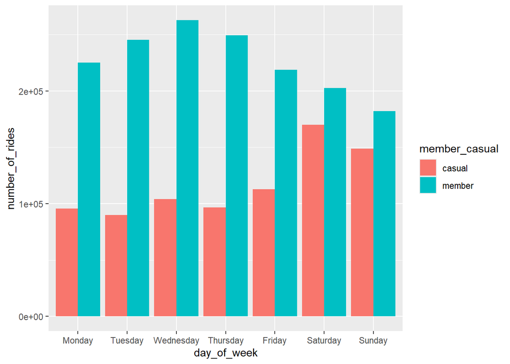

```r
summarized_data <- all_trips_v2 %>%
  group_by(member_casual, day_of_week) %>%
  summarise(number_of_rides = n(), .groups = "drop") %>%
  arrange(day_of_week)

ggplot(data = summarized_data, aes(x = day_of_week, y = number_of_rides, fill = member_casual)) +
  geom_bar(position = "dodge", stat = "identity")
```

```r
all_trips_v2 %>%
  group_by(member_casual,day_of_week) %>%
  summarise(sum(duration),.groups ="drop") %>%
  arrange(day_of_week)
```

```
## # A tibble: 14 × 3
##    member_casual day_of_week `sum(duration)`
##    <chr>         <ord>                 <dbl>
##  1 casual        Monday           148911664.
##  2 member        Monday           171549698.
##  3 casual        Tuesday          125493595.
##  4 member        Tuesday          187832213.
##  5 casual        Wednesday        147237561.
##  6 member        Wednesday        204465126.
##  7 casual        Thursday         131801809.
##  8 member        Thursday         185896720.
##  9 casual        Friday           176316722.
## 10 member        Friday           163167936.
## 11 casual        Saturday         304725949.
## 12 member        Saturday         175212278.
## 13 casual        Sunday           276212452.
## 14 member        Sunday           161704294.
```

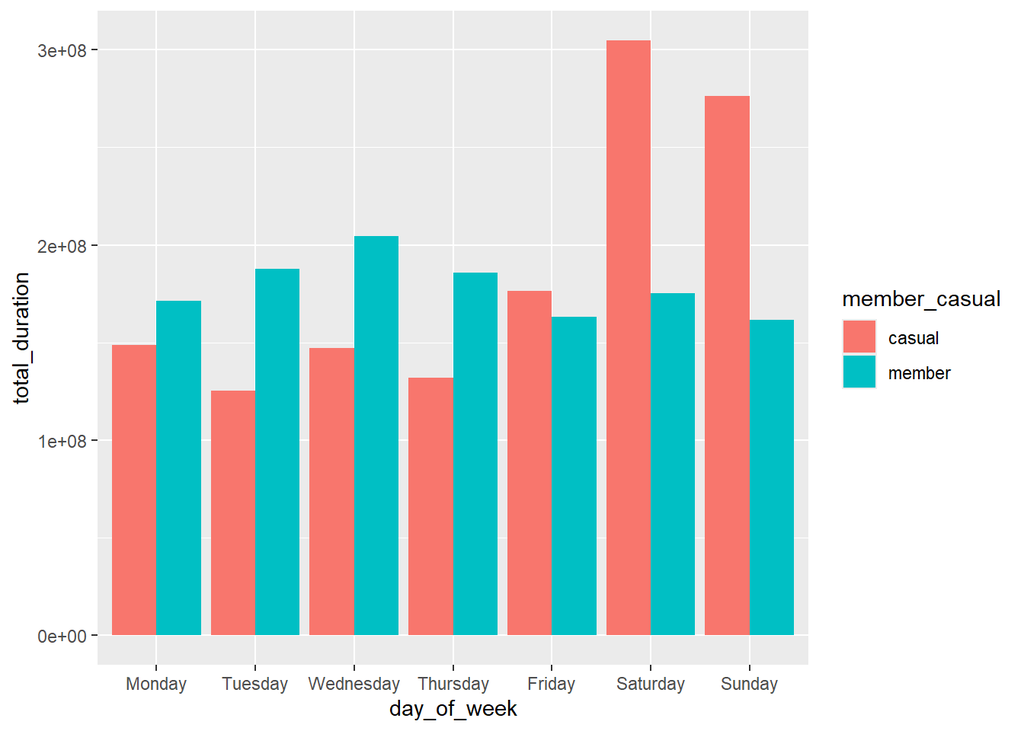

```r
summarized_data <- all_trips_v2 %>%
  group_by(member_casual,day_of_week) %>%
  summarise (total_duration=sum(duration),.groups ="drop") %>%
  arrange(day_of_week)
    ggplot(data = summarized_data, aes(x = day_of_week, y = total_duration, fill = member_casual)) +
  geom_bar(position = "dodge", stat = "identity")
```

```r
all_trips_v2 %>%
  group_by(month,member_casual) %>%
  summarise(number_of_rides=n(),.groups = "drop")%>%
  arrange(month)
```

```
## # A tibble: 12 × 3
##    month member_casual number_of_rides
##    <chr> <chr>                   <int>
##  1 01    casual                  24448
##  2 01    member                 120348
##  3 02    casual                  47159
##  4 02    member                 175982
##  5 03    casual                  82517
##  6 03    member                 219089
##  7 04    casual                 131766
##  8 04    member                 283129
##  9 05    casual                 230945
## 10 05    member                 378363
## 11 06    casual                 300995
## 12 06    member                 409515
```

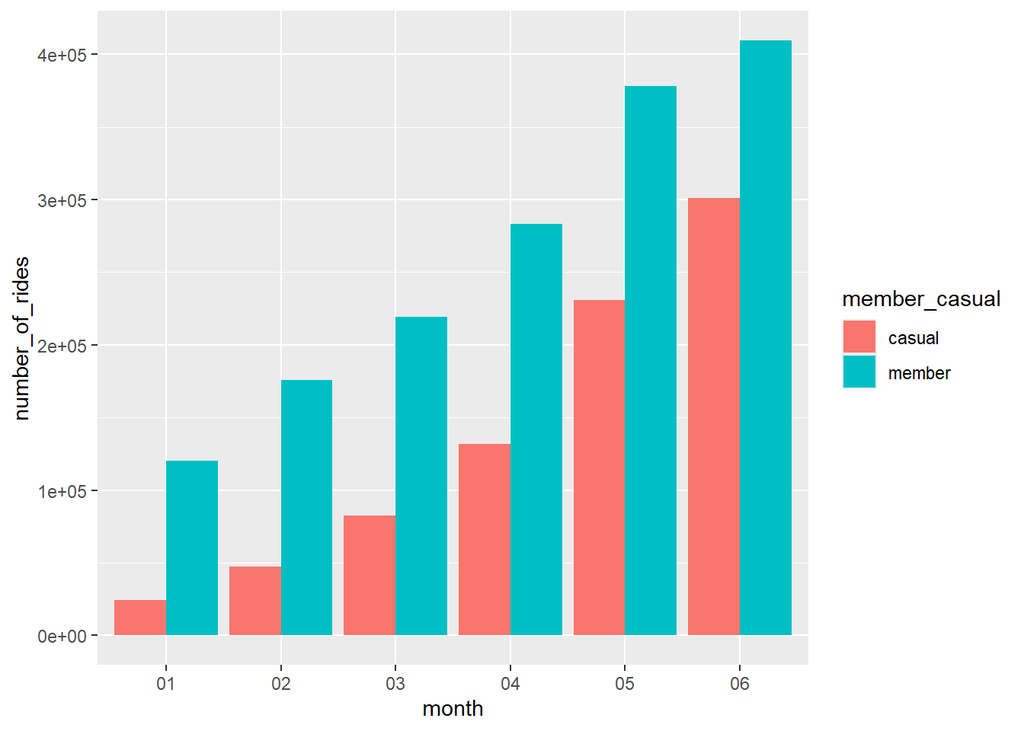

```r
all_trips_v2 %>%
  group_by(month,member_casual) %>%
  summarise(number_of_rides=n(),.groups = "drop")%>%
  arrange(month)%>%
  ggplot(aes(x=month,y=number_of_rides,fill=member_casual))+
  geom_bar(position = "dodge", stat = "identity")
```

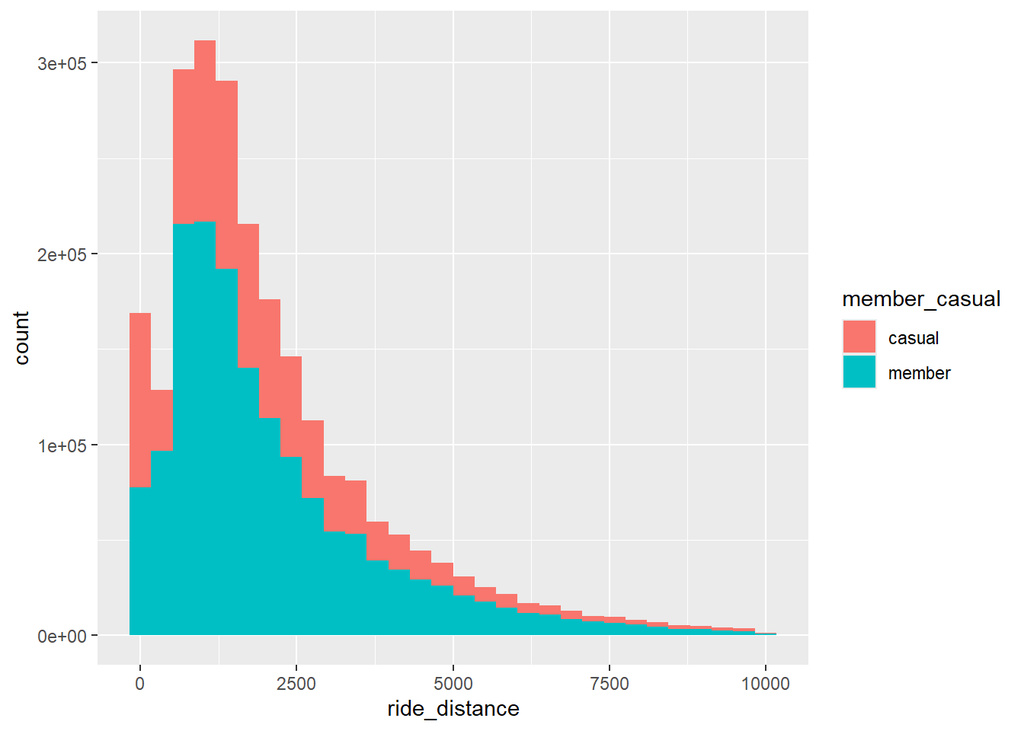

```r
all_trips_v2 %>%
  group_by(member_casual) %>%
  filter(ride_distance < 10000)%>%
  ggplot(aes(x = ride_distance, fill = member_casual)) +
  geom_histogram()
```

It looks like casual users take longer bike rides compared to regular members. This suggests that casual users might use the bikes more for fun or leisure, while regular members might use them more for practical reasons, like commuting.

Share

Conclusion:

*Casual users tend to use the bikes for leisure and tourism, especially on weekends, which suggests they enjoy longer rides and recreational activities.

*Annual users primarily use the bikes for commuting or practical purposes during weekdays, indicating a more routine and functional use of the service.

*Annual users are more likely to incorporate biking into their daily routines, possibly for work or other regular activities, resulting in shorter and more frequent rides during the workweek.

*The difference in ride patterns highlights the diverse ways people utilize bike-sharing services, with casual users focusing on enjoyment and annual users on practicality.